# Professor: Alejandro Llorente Pinto

# Section 5

## Visualizing shortest paths

On this previous subgraph, you have to compute:

1. The shortest path from the node with the highest degree to the rest of the graph.
2. From all these paths, select one path with the maximum length.
3. Visualize only this path using the plot function.
4. Visualize this path within the giant component subgraph.

To this end, use the layout.fruchterman.reingold function to place the nodes in the visualization.

```r
# 1. The shortest path from the node with the highest degree to the rest of the graph
max_degree = which.max(degree(g3))
shortest = get.shortest.paths(g3, max_degree)
# 2. From all these paths, select one path with the maximum length
lengths_paths = sapply(shortest$vpath, length)
head(sort(lengths_paths, decreasing = T))
```

```
## [1] 7 6 6 6 6 6
```

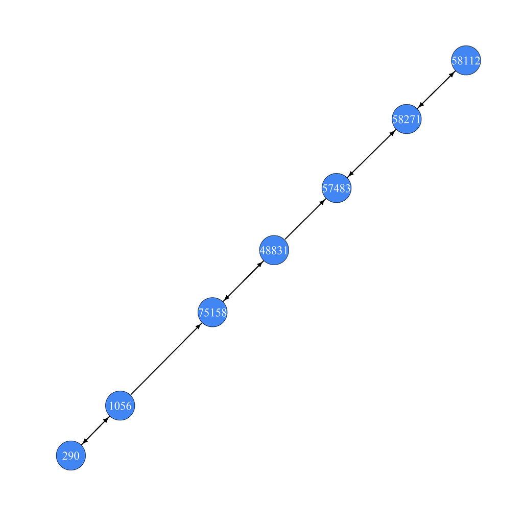

```r
max_length_index = which.max(lengths_paths)
shortest_path = shortest$vpath[max_length_index]
index_shortest = unlist(shortest_path)
# 3. Visualize only this path using the plot function
sub1 = subgraph(g3, index_shortest)
plot.igraph(sub1, vertex.label.cex=2, vertex.color = "#4286f4",
            vertex.label.color ="white", vertex.size = 15, edge.color = "black",
            edge.width = 3, edge.arrow.size =1)
```

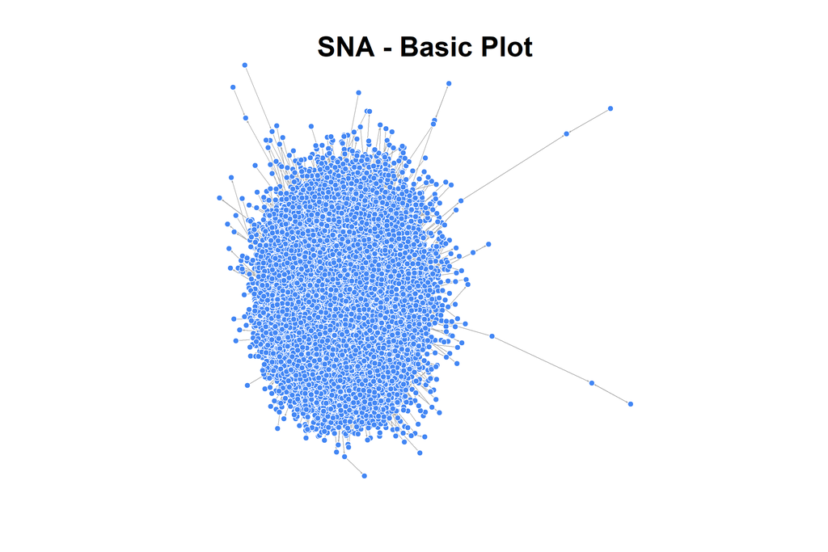

```
## integer(0)
```

```r
# 4. Visualize this path within the giant component subgraph
## Basic plot of all nodes without highlighting shortest path
#png("giant_component_basic.png",width = 3840, height = 2160) +
plot(g3, layout=layout.fruchterman.reingold(g3),
       vertex.label.cesx=3, edge.arrow.size=.15, vertex.label = NA,
       vertex.size = 3, vertex.frame.color = "white", vertex.frame.width = "5",
     vertex.color = "#4286f4", line = -3)+
  title(main="SNA - Basic Plot", col.main="black", font.main = 2,
        cex.main = 3,
        xlab="", ylab="",
        col.lab="green", cex.lab=15, line = -1)
```

- Plot of all nodes highlighting shortest path
  - Coloring nodes
  - Coloring edges
  - Modifying Node Sizes
  - Modifying Labels and fonts
  - Modifying Edge Widths
  - Customising the layout’s coordinates

```r
## 5. Plot of all nodes highlighting shortest path
### 5.1. Coloring nodes
g3.1 = g3
V(g3.1)$color <- "#4286f4"
V(g3.1)[index_shortest]$color = "#4286f4"
V(g3.1)[57]$color = "#33cc33" # Ending node of shortest path
### 5.2. Coloring Edges
Edge_IDS = get.edge.ids(g3.1, c(57, 321, 321, 15569, 15569, 8142, 8142, 8654, 8654, 8697, 8697, 14734))
E(g3.1)$color <- "grey"
E(g3.1)[Edge_IDS]$color <- "red"
V(g3.1)[index_shortest]$edge.width = "20"
### 5.3. Node Sizes
node.size = setNames( rep(3,vcount(g3.1)),V(g3.1))
node.size[index_shortest] = 20
node.size[57] = 30
### 5.4. Labels and fonts
V(g3.1)$label = ""
V(g3.1)[index_shortest]$label = V(g3.1)[index_shortest]$name
V(g3.1)$label.cex = 3
V(g3.1)[57]$label.cex = 5.5
### 5.5. Edge Widths
E(g3.1)$e_width = 2
E(g3.1)[Edge_IDS]$e_width = 10
### 5.6. Customising the layout
cutsom_layout = layout.fruchterman.reingold(g3.1)
#### 5.7. Padding all the nodes downwards
cutsom_layout[,2] = cutsom_layout[,2] - 10
#### 5.8. Layout for shortest path nodes
cutsom_layout[57,] = c(cutsom_layout[57,][1]-20,cutsom_layout[57,][2]+7)
cutsom_layout[321,] = c(cutsom_layout[321,][1]-12,cutsom_layout[57,][2])
cutsom_layout[15569,] = c(cutsom_layout[15569,][1]-5,cutsom_layout[57,][2])
cutsom_layout[8142,] = c(cutsom_layout[8142,][1],cutsom_layout[57,][2])
cutsom_layout[8654,] = c(cutsom_layout[8654,][1]+7, cutsom_layout[57,][2])
cutsom_layout[8697,] = c(cutsom_layout[8697,][1]+12,cutsom_layout[57,][2])
cutsom_layout[14734,] = c(cutsom_layout[14734,][1]+17,cutsom_layout[57,][2])
```

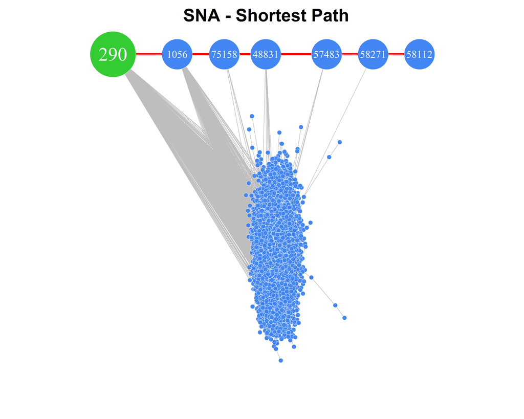

```
## integer(0)
```

```r
### 5.9. Printing and saving graph with shortest path
plot(g3.1, layout=cutsom_layout, vertex.label.cesx=3, edge.arrow.size=.15,edge.width=E(g3.1)$e_width,
     vertex.size =node.size, vertex.label= V(g3.1)$label, vertex.frame.color = "white",
     vertex.label.color = "white") +
  title(main="SNA - Shortest Path", col.main="black", font.main = 2,
        cex.main = 5,
        xlab="", ylab="",
        col.lab="green", cex.lab=15, line = -1)
```

```r
# Save to PNG file
#png("giant_component.png",width = 3840, height = 2160) +
#plot(g3.1, layout=cutsom_layout, vertex.label.cesx=3, edge.arrow.size=.15,edge.width=E(g3.1)$e_width,
#     vertex.size =node.size, vertex.label= V(g3.1)$label, vertex.frame.color = "yellow") +
#  title(main="SNA - Shortest Path", col.main="black", font.main = 2,
#        cex.main = 10,
#        sub="Done By: Hernando Suarez & Hani Eid", col.sub="blue", cex.sub = 5,
#        xlab="", ylab="",
#        col.lab="green", cex.lab=15, line = -4)
#dev.off()
```